# Analyzing Individual BGG Users

Phil Henrickson

2022-01-01

# **Volnay’s** BoardGameGeek Collection

This notebook contains a set of analyses for the selected user’s boardgamegeek collection. The bulk of the analysis is focused on building a user-specific predictive model to predict the games that Volnay is likely to own. This enables to ask questions like, based on the games the user currently owns, what games are a good fit for their collection? What upcoming games are they likely to purchase?

This analysis is based on data from BoardGameGeek that was last updated on **2021-12-20.**

# 1 Collection Overview

We can look at a basic description of the number of games that the user owns, has rated, has previously owned, etc.

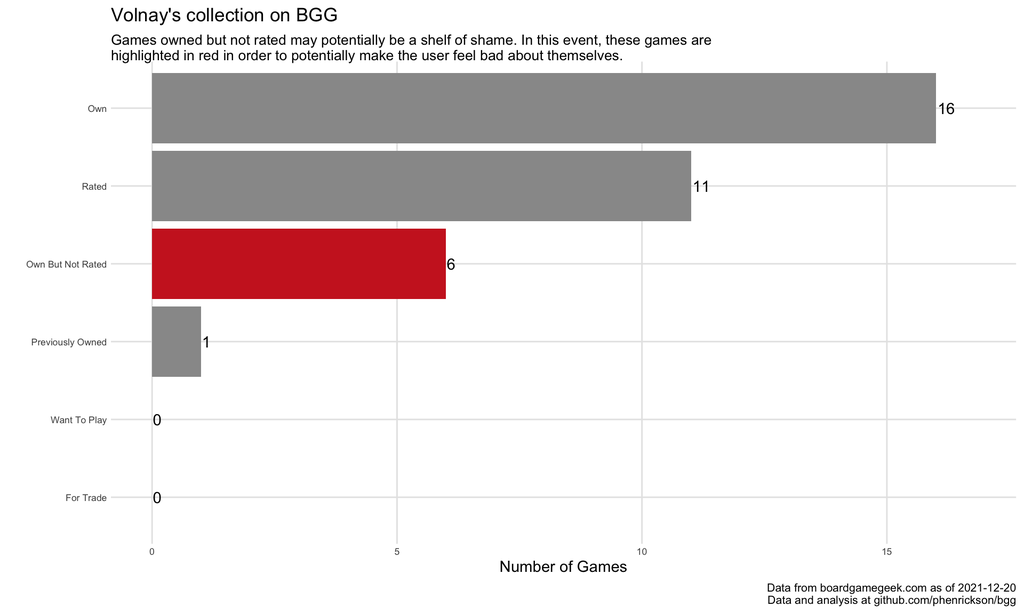

What years has the user owned/rated games from? While we can’t see when a user added or removed a game from their collection, we can look at their collection by the years in which their games were published.

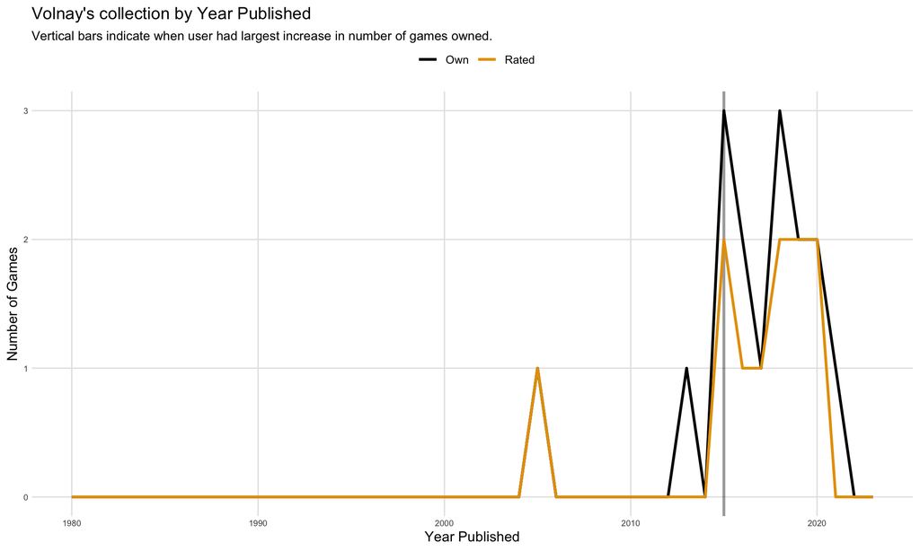

## 1.1 What types of games does Volnay own?

We can look at the most frequent types of categories, mechanics, designers, and artists that appear in a user’s collection.

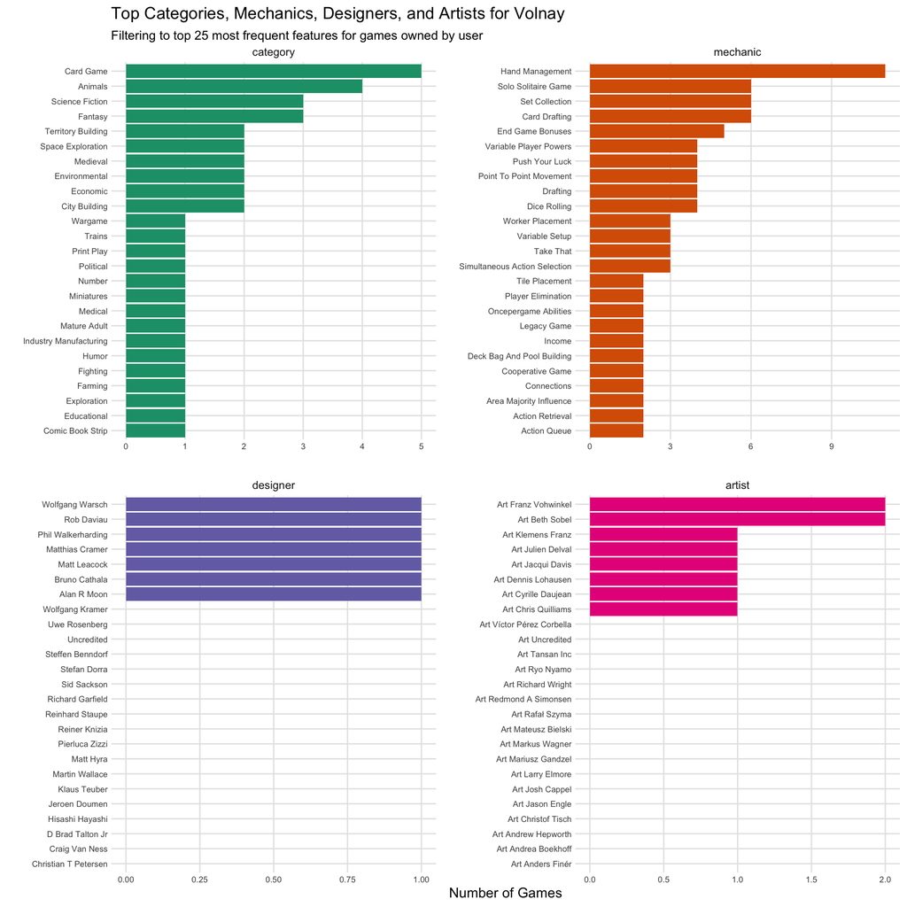

# 2 Modeling **Volnay’s** Collection

| username | dataset | period | games_owned | games_rated | games_played |
| --- | --- | --- | --- | --- | --- |
| Volnay | training | published before 2020 | 13 | 9 | 14 |
| Volnay | test | published 2020 or later | 3 | 2 | 3 |

There are two main (binary) outcomes we will be modeling for the user.

The first, **own** refers to whether the user currently lists a game as owned in their collection. The second, **played** refers to whether the user currently owns, has rated, or previously owned a game. This means the latter will generally have a larger list of games, but may still be a useful category to examine for people who play lots of games without necessarily owning them.

We will train predictive models to learn the probability that the user will own or play individual games based on their features.

## 2.1 Coefficients for Volnay

We can examine coefficients from the trained modes, which are penalized logistic regressions fit to our two main outcomes. Positive values indicate that a feature increases a user’s probabilility of owning/rating a game, while negative values indicate a feature decreases the probability.

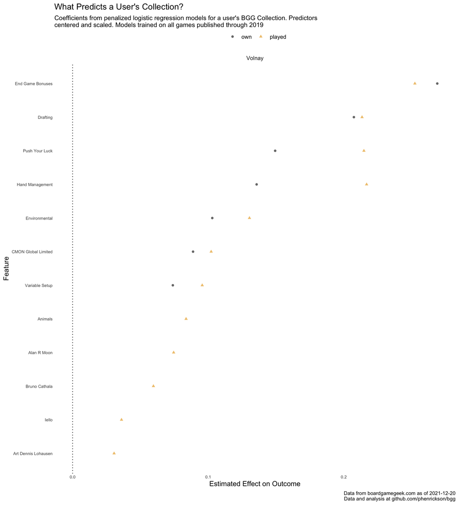

## 2.2 Visualizing Predictors for Volnay’s Collection

Why did the model identify these features? We can make density plots of the important features for predicting whether the user owned a game. Blue indicates the density for games owned by the user, while grey indicates the density for games not owned by the user.

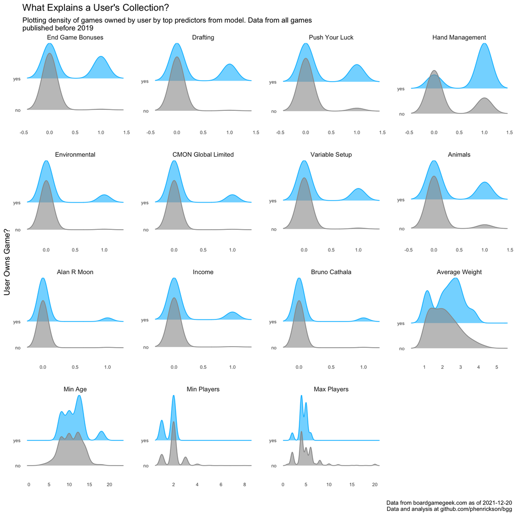

Binary predictors can be difficult to see with this visualization, so we can also directly examine the percentage of games in a user’s collection with a predictor vs the percentage of all games with that predictor.

| username | Feature | % of Games with Feature In_Collection | % of Games with Feature All_Games | Ratio |
| --- | --- | --- | --- | --- |
| Volnay | End Game Bonuses | 38.5% | 1.2% | 31.0 |
| Volnay | Drafting | 30.8% | 1.0% | 30.5 |
| Volnay | Income | 15.4% | 0.7% | 21.5 |
| Volnay | CMON Global Limited | 15.4% | 0.8% | 19.0 |
| Volnay | Environmental | 15.4% | 1.1% | 13.9 |
| Volnay | Variable Setup | 23.1% | 1.9% | 12.3 |
| Volnay | Push Your Luck | 30.8% | 5.3% | 5.8 |
| Volnay | Animals | 30.8% | 6.9% | 4.5 |
| Volnay | City Building | 15.4% | 4.3% | 3.6 |
| Volnay | Trains | 7.7% | 2.2% | 3.5 |
| Volnay | Hand Management | 76.9% | 26.7% | 2.9 |
| Volnay | Medieval | 15.4% | 6.3% | 2.4 |
| Volnay | Horror | 0.0% | 4.0% | 0.0 |
| Volnay | Word Game | 0.0% | 1.8% | 0.0 |
| Volnay | Negotiation | 0.0% | 3.7% | 0.0 |
| Volnay | Trivia | 0.0% | 1.8% | 0.0 |
| Volnay | Puzzle | 0.0% | 3.4% | 0.0 |
| Volnay | Party Game | 0.0% | 8.5% | 0.0 |
| Volnay | Racing | 0.0% | 2.8% | 0.0 |
| Volnay | Action Dexterity | 0.0% | 4.8% | 0.0 |
| Volnay | Mafia | 0.0% | 0.7% | 0.0 |
| Volnay | Prehistoric | 0.0% | 1.0% | 0.0 |
| Volnay | Realtime | 0.0% | 4.2% | 0.0 |
| Volnay | Sports | 0.0% | 2.0% | 0.0 |
| Volnay | Deduction Game | 0.0% | 6.4% | 0.0 |

# 3 Assess Model’s Performance on Training Set

Before predicting games in upcoming years, we can examine how well the model did and what games it liked in the training set. In this case, we used resampling techniques (cross validation) to ensure that the model had not seen a game before making its predictions.

## 3.1 Separation Plot

An easy way to examine the performance of classification model is to view a separation plot. We plot the predicted probabilities from the model for every game (from resampling) from lowest to highest. We then overlay a blue line for any game that the user does own. A good classifier is one that is able to *separate* the blue (games owned by the user) from the white (games not owned by the user), with most of the blue occurring at the highest probabilities (right side of the chart).

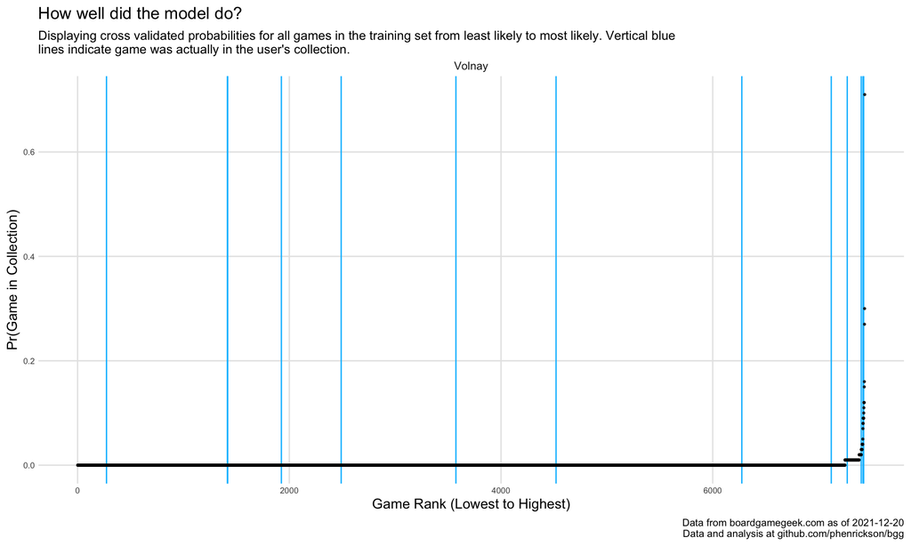

## 3.2 Top Games for **Volnay** from Training Set

We can display this information in table form, displaying the 100 games with the highest probability of ownership, adding a blue line when the user does own the game.

| username | yearpublished | game_id | name | pred_played | pred_own | actual_played | actual_own |
| --- | --- | --- | --- | --- | --- | --- | --- |
| Volnay | 2018 | 244711 | Newton | 0.42 | 0.71 | 0 | 0 |
| Volnay | 2018 | 205896 | Rising Sun | 0.58 | 0.30 | 0 | 0 |
| Volnay | 2016 | 185589 | Islebound | 0.20 | 0.27 | 0 | 0 |
| Volnay | 2019 | 265736 | Tiny Towns | 0.17 | 0.16 | 0 | 0 |
| Volnay | 2015 | 181687 | The Pursuit of Happiness | 0.17 | 0.15 | 0 | 0 |
| Volnay | 2019 | 260710 | Amul | 0.14 | 0.12 | 0 | 0 |
| Volnay | 2016 | 192291 | Sushi Go Party! | 0.11 | 0.12 | 0 | 0 |
| Volnay | 2017 | 217861 | Paper Tales | 0.08 | 0.12 | 0 | 0 |
| Volnay | 2017 | 184921 | Bunny Kingdom | 0.35 | 0.11 | 0 | 0 |
| Volnay | 2019 | 261342 | Old West Empresario | 0.02 | 0.10 | 0 | 0 |
| Volnay | 2019 | 283863 | The Magnificent | 0.14 | 0.09 | 0 | 0 |
| Volnay | 2019 | 276025 | Maracaibo | 0.05 | 0.09 | 0 | 0 |
| Volnay | 2016 | 72321 | The Networks | 0.11 | 0.09 | 0 | 0 |
| Volnay | 2004 | 9209 | Ticket to Ride | 0.11 | 0.09 | 0 | 0 |
| Volnay | 2016 | 167791 | Terraforming Mars | 0.05 | 0.09 | 1 | 1 |
| Volnay | 2019 | 266192 | Wingspan | 0.08 | 0.08 | 1 | 1 |
| Volnay | 2019 | 271324 | It's a Wonderful World | 0.08 | 0.08 | 0 | 0 |
| Volnay | 2019 | 251247 | Barrage | 0.02 | 0.07 | 0 | 0 |
| Volnay | 2018 | 252929 | Planet | 0.06 | 0.05 | 0 | 0 |
| Volnay | 2014 | 157354 | Five Tribes | 0.06 | 0.04 | 0 | 0 |
| Volnay | 2017 | 218603 | Photosynthesis | 0.02 | 0.04 | 0 | 0 |
| Volnay | 2017 | 220308 | Gaia Project | 0.08 | 0.04 | 0 | 0 |
| Volnay | 2011 | 70919 | Takenoko | 0.03 | 0.04 | 0 | 0 |
| Volnay | 2014 | 167298 | Sheep & Thief | 0.05 | 0.04 | 0 | 0 |
| Volnay | 2005 | 18258 | Mission: Red Planet | 0.04 | 0.04 | 0 | 0 |
| Volnay | 2018 | 222219 | Kero | 0.01 | 0.03 | 0 | 0 |
| Volnay | 2016 | 155821 | Inis | 0.01 | 0.03 | 0 | 0 |
| Volnay | 2018 | 247763 | Underwater Cities | 0.02 | 0.03 | 0 | 0 |
| Volnay | 2019 | 266507 | Clank!: Legacy – Acquisitions Incorporated | 0.18 | 0.03 | 0 | 0 |
| Volnay | 2010 | 62219 | Dominant Species | 0.03 | 0.03 | 0 | 0 |

[output cut: 70 more lines]

We can also more formally assess how well the model did in resampling by looking at the area under the receiver operating characteristic. A perfect model would receive a score of 1, while a model that cannot predict the outcome will default to a score of 0.5. The extent to which something is a *good* score depends on the setting, but generally anything in the .8 to .9 range is very good while the .7 to .8 range is perfectly acceptable.

| username | outcome_type | .metric | .estimator | .estimate |
| --- | --- | --- | --- | --- |
| Volnay | own | roc_auc | binary | 0.776 |
| Volnay | played | roc_auc | binary | 0.697 |

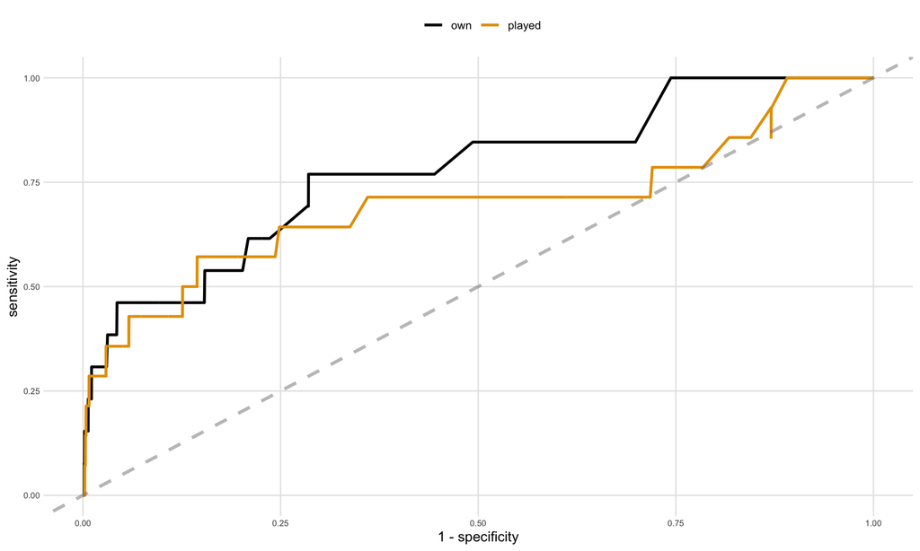

Another way to think about the model performance is to view its lift, or its ability to detect the positive outcomes over that of a null model. High lift indicates the model can much more quickly find all of the positive outcomes (in this case, games owned or played by the user), while a model with no lift is no better than random guessing.

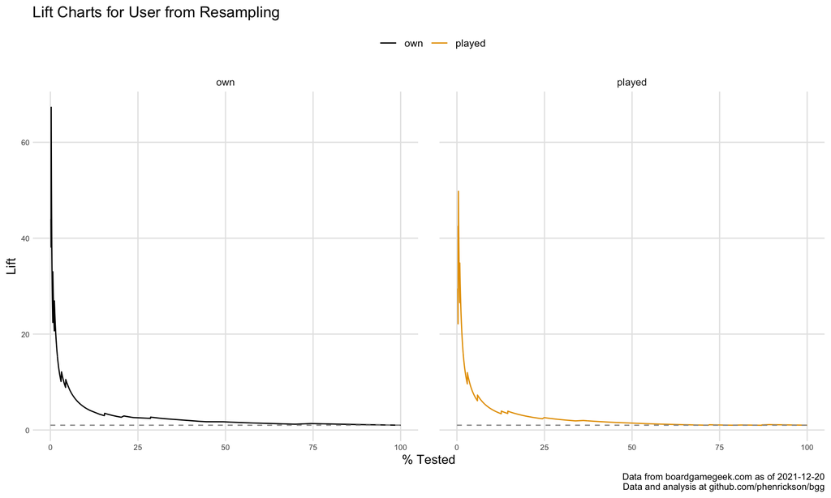

## 3.3 Most and Least Likely Games

What games does the model think Volnay is **most likely to own** that are **not** in their collection?

| username | yearpublished | game_id | name | pred_own | actual_own |
| --- | --- | --- | --- | --- | --- |
| Volnay | 2018 | 244711 | Newton | 0.71 | 0 |
| Volnay | 2018 | 205896 | Rising Sun | 0.30 | 0 |
| Volnay | 2016 | 185589 | Islebound | 0.27 | 0 |
| Volnay | 2019 | 265736 | Tiny Towns | 0.16 | 0 |
| Volnay | 2015 | 181687 | The Pursuit of Happiness | 0.15 | 0 |

What games does the model think Volnay is **least likely to own** that **are** in their collection?

| username | yearpublished | game_id | name | pred_own | actual_own |
| --- | --- | --- | --- | --- | --- |
| Volnay | 2019 | 274364 | Watergate | 0 | 1 |
| Volnay | 2017 | 233371 | Clank! In! Space!: A Deck-Building Adventure | 0 | 1 |
| Volnay | 2018 | 237182 | Root | 0 | 1 |
| Volnay | 2015 | 161936 | Pandemic Legacy: Season 1 | 0 | 1 |
| Volnay | 2018 | 244521 | The Quacks of Quedlinburg | 0 | 1 |

## 3.4 Top Games by Year

Top 25 games most likely to be owned by the user in each year, highlighting in blue the games that the user has owned/played.

| rank | 2011 | 2012 | 2013 | 2014 | 2015 | 2016 | 2017 | 2018 | 2019 |
| --- | --- | --- | --- | --- | --- | --- | --- | --- | --- |
| 1 | Takenoko | Terra Mystica | Sushi Go! | Five Tribes | The Pursuit of Happiness | Islebound | Paper Tales | Newton | Tiny Towns |
| 2 | Band of Brothers: Screaming Eagles | Tokaido | Legacy: The Testament of Duke de Crecy | Sheep & Thief | Grand Austria Hotel | Sushi Go Party! | Bunny Kingdom | Rising Sun | Amul |
| 3 | A Few Acres of Snow | Targi | Castle Dice | Alchemists | Nevermore | The Networks | Photosynthesis | Planet | Old West Empresario |
| 4 | Sekigahara: The Unification of Japan | Tzolk'in: The Mayan Calendar | Russian Railroads | Pandemic: The Cure | Coffee Roaster | Terraforming Mars | Gaia Project | Kero | The Magnificent |
| 5 | Fighting Formations: Grossdeutschland Motorized Infantry Division | Seasons | Tomorrow | Patchwork | Haspelknecht | Inis | Pulsar 2849 | Underwater Cities | Maracaibo |
| 6 | No Retreat! The Russian Front | Kairo | Brew Crafters | Imperial Settlers | Blood Rage | Avenue | Gateway: Uprising | Architects of the West Kingdom | Wingspan |
| 7 | Nightfighter | Santa Cruz | Mount Everest | Abyss | My Village | Hit Z Road | Pandemic Legacy: Season 2 | Haven | It's a Wonderful World |
| 8 | Space Infantry | Among the Stars | Dungeon Command: Blood of Gruumsh | La Granja | Inhabit the Earth | Clank!: A Deck-Building Adventure | Sagrada | Coimbra | Barrage |
| 9 | No Peace Without Spain!: The War of the Spanish Succession 1702-1713 | Keyflower | Band of Brothers: Ghost Panzer | Camel Up | Far Space Foundry | Capital Lux | Azul | Western Legends | Clank!: Legacy – Acquisitions Incorporated |
| 10 | FAB: Sicily | The Manhattan Project | BattleLore: Second Edition | Three Kingdoms Redux | Council of 4 | Agricola (Revised Edition) | Pocket Mars | A Song of Ice & Fire: Tabletop Miniatures Game – Stark vs Lannister Starter Set | Era: Medieval Age |
| 11 | Revolver | Kings of War | No Retreat!: The North African Front | Evolution | The Bloody Inn | Yokohama | Clans of Caledonia | Dice Hospital | Coloma |
| 12 | 1955: The War of Espionage | Mage Wars Arena | Crusade and Revolution: The Spanish Civil War, 1936-1939 | Spurs: A Tale in the Old West | Best Treehouse Ever | Quadropolis | Tournament Fishing: The Deckbuilding Game | Everdell | Crystal Palace |
| 13 | Test of Fire: Bull Run 1861 | Dungeon Command: Sting of Lolth | Sedition Wars: Battle for Alabaster | Fallen | New Salem | Imhotep | Rum & Bones: Second Tide | The Tea Dragon Society Card Game | Monster Baby Rescue! |
| 14 | Steam Torpedo: First Contact | Dungeon Command: Heart of Cormyr | Dungeon Twister: The Card Game | Holdfast: Russia 1941-42 | Between Two Cities | Banana Bandits | Ethnos | The Grizzled: Armistice Edition | De Vulgari Eloquentia: Deluxe Edition |
| 15 | Yomi | Dungeon Command: Curse of Undeath | Invaders | Heroes of Normandie | Zombicide: Black Plague | Evolution: Climate | Massive Darkness | Blue Lagoon | Paris: La Cité de la Lumière |
| 16 | Laser Chess | DreadBall: The Futuristic Sports Game | Risk: Plants vs. Zombies | Strife: Legacy of the Eternals | RYŪ | Monstrous | The Godfather: Corleone's Empire | Azul: Stained Glass of Sintra | The Isle of Cats |
| 17 | Omen: A Reign of War | Kingdom of Heaven: The Crusader States 1097-1291 | Metallum | Star Wars: Empire vs. Rebellion | Tiny Epic Galaxies | Black Orchestra | Peak Oil | That's Pretty Clever! | Yukon Airways |
| 18 | Ascension: Return of the Fallen | Celles: The Ardennes, December 23-27, 1944 | France '40 | Fleet Commander: 1 – Ignition | The Grizzled | Dynasties: Heirate & Herrsche | Calimala | Gingerbread House | Sierra West |
| 19 | Drako: Dragon & Dwarves | Antike Duellum | Castellan | Jäger und Späher | Exploding Kittens | Thief's Market | Unfair | The Little Flower Shop | The Taverns of Tiefenthal |
| 20 | Kulami | Game of Thrones: The Card Game | Island Siege | Space Hulk (Fourth Edition) | FUSE | The Manhattan Project: Energy Empire | Journal 29: Interactive Book Game | Sprawlopolis | Minecraft: Builders & Biomes |
| 21 | Hemloch | For the Crown (Second Edition) | Smash Up: Awesome Level 9000 | Wir sind das Volk! | Stronghold: 2nd edition | Scythe | Techno Bowl: Arcade Football Unplugged | Pax Emancipation | Aquatica |
| 22 | Infidel | 1989: Dawn of Freedom | Pixel Tactics 2 | The Battle of Five Armies | Wing Leader: Victories 1940-1942 | Old School Tactical: Volume 1 – Fighting on the Eastern Front 1941/42 | Commands & Colors Tricorne: The American Revolution | Key Flow | Last Bastion |
| 23 | Advanced Squad Leader: Starter Kit Expansion Pack #1 | Mr. Madison's War: The Incredible War of 1812 | Smash Up: The Obligatory Cthulhu Set | Ortus Regni | Warhammer Age of Sigmar | Silent Victory: U.S. Submarines in the Pacific, 1941-45 | Runewars Miniatures Game | Trekking the National Parks: Second Edition | Azul: Summer Pavilion |
| 24 | Carnac | Nuklear Winter '68 | The Ravens of Thri Sahashri | Smash Up: Science Fiction Double Feature | The U.S. Civil War | Wing Leader: Supremacy 1943-1945 | Aristeia! | Kodama Duo | Herbaceous Sprouts |
| 25 | Battle of LITS | Revolver 2: Last Stand at Malpaso | The Dark Valley | Pagoda | Guild Ball | MBT (Second Edition) | Fields of Despair: France 1914-1918 | Gettysburg | The Towers of Arkhanos |

## 3.5 Interactive Predictions from Resampling

Interactive table for predictions from resampling.

|  | username | yearpublished | rank | game_id | name | pred_played | pred_own | actual_played | actual_own |
| --- | --- | --- | --- | --- | --- | --- | --- | --- | --- |
| 1 | Volnay | 1900 | 202 | 5546 | Marbles | 0 | 0 | 0 | 0 |
| 2 | Volnay | 1900 | 205 | 11901 | Tic-Tac-Toe | 0 | 0 | 0 | 0 |
| 3 | Volnay | 1900 | 255 | 188 | Go | 0 | 0 | 0 | 0 |
| 4 | Volnay | 1900 | 370 | 171 | Chess | 0 | 0 | 0 | 0 |
| 5 | Volnay | 1900 | 381 | 2065 | Shogi | 0 | 0 | 0 | 0 |
| 6 | Volnay | 1900 | 383 | 2393 | Xiangqi | 0 | 0 | 0 | 0 |
| 7 | Volnay | 1900 | 624 | 26952 | International Checkers | 0 | 0 | 0 | 0 |
| 8 | Volnay | 1900 | 661 | 1602 | The Royal Game of Ur | 0 | 0 | 0 | 0 |
| 9 | Volnay | 1900 | 662 | 2083 | Checkers | 0 | 0 | 0 | 0 |
| 10 | Volnay | 1900 | 670 | 2389 | Othello | 0 | 0 | 0 | 0 |

[output cut: 7426 more lines]

# 4 Validating the Model on 2020

How well did a model trained on a user’s collection through 2019 perform in predicting games for the user from 2020?

| username | outcome_type | yearpublished | .metric | .estimator | .estimate |
| --- | --- | --- | --- | --- | --- |
| Volnay | own | 2020 | roc_auc | binary | 0.508 |
| Volnay | played | 2020 | roc_auc | binary | 0.628 |

Table of top 25 games from 2020, highlighting games that the user owns.

| username | yearpublished | game_id | name | pred_own | pred_played | actual_own | actual_played |
| --- | --- | --- | --- | --- | --- | --- | --- |
| Volnay | 2020 | 297204 | Traintopia | 0.12 | 0.12 | 0 | 0 |
| Volnay | 2020 | 184267 | On Mars | 0.10 | 0.10 | 0 | 0 |
| Volnay | 2020 | 299960 | Alma Mater | 0.10 | 0.10 | 0 | 0 |
| Volnay | 2020 | 307844 | Atheneum: Mystic Library | 0.08 | 0.07 | 0 | 0 |
| Volnay | 2020 | 297030 | Tekhenu: Obelisk of the Sun | 0.03 | 0.05 | 0 | 0 |
| Volnay | 2020 | 298371 | Wild Space | 0.03 | 0.04 | 0 | 0 |
| Volnay | 2020 | 256317 | Guild Master | 0.02 | 0.01 | 0 | 0 |
| Volnay | 2020 | 277927 | Bites | 0.02 | 0.02 | 0 | 0 |
| Volnay | 2020 | 300081 | Hideous Abomination | 0.02 | 0.02 | 0 | 0 |
| Volnay | 2020 | 300322 | Hallertau | 0.02 | 0.02 | 0 | 0 |
| Volnay | 2020 | 302840 | Carcata | 0.02 | 0.02 | 0 | 0 |
| Volnay | 2020 | 308765 | Praga Caput Regni | 0.02 | 0.02 | 0 | 0 |
| Volnay | 2020 | 310885 | Belaad: The Land of Swords and Quills | 0.02 | 0.02 | 0 | 0 |
| Volnay | 2020 | 311193 | Anno 1800 | 0.02 | 0.02 | 0 | 0 |
| Volnay | 2020 | 313698 | Monster Expedition | 0.02 | 0.03 | 0 | 0 |
| Volnay | 2020 | 320819 | Dinner in Paris | 0.02 | 0.01 | 0 | 0 |
| Volnay | 2020 | 220133 | Endangered | 0.01 | 0.01 | 0 | 0 |
| Volnay | 2020 | 227224 | The Red Cathedral | 0.01 | 0.01 | 0 | 0 |
| Volnay | 2020 | 252153 | Tang Garden | 0.01 | 0.01 | 0 | 0 |
| Volnay | 2020 | 253506 | Versailles 1919 | 0.01 | 0.01 | 0 | 0 |
| Volnay | 2020 | 254888 | High Rise | 0.01 | 0.01 | 0 | 0 |
| Volnay | 2020 | 267009 | Rome & Roll | 0.01 | 0.01 | 0 | 0 |
| Volnay | 2020 | 270143 | Kōhaku | 0.01 | 0.01 | 0 | 0 |
| Volnay | 2020 | 271002 | Myraclia | 0.01 | 0.01 | 0 | 0 |
| Volnay | 2020 | 279198 | Tungaru | 0.01 | 0.01 | 0 | 0 |

# 5 Predicting Upcoming Games (2020 and On) for **Volnay**

Examine the top games for the test set.

| username | yearpublished | game_id | name | rank | own | played |
| --- | --- | --- | --- | --- | --- | --- |
| Volnay | 2020 | 297204 | Traintopia | 1 | 0.12 | 0.12 |
| Volnay | 2020 | 299960 | Alma Mater | 2 | 0.10 | 0.10 |
| Volnay | 2020 | 184267 | On Mars | 3 | 0.10 | 0.10 |
| Volnay | 2020 | 307844 | Atheneum: Mystic Library | 4 | 0.08 | 0.07 |
| Volnay | 2020 | 298371 | Wild Space | 5 | 0.03 | 0.04 |
| Volnay | 2020 | 297030 | Tekhenu: Obelisk of the Sun | 6 | 0.03 | 0.05 |
| Volnay | 2020 | 256317 | Guild Master | 7 | 0.02 | 0.01 |
| Volnay | 2020 | 320819 | Dinner in Paris | 8 | 0.02 | 0.01 |
| Volnay | 2020 | 300322 | Hallertau | 9 | 0.02 | 0.02 |
| Volnay | 2020 | 300081 | Hideous Abomination | 10 | 0.02 | 0.02 |
| Volnay | 2020 | 311193 | Anno 1800 | 11 | 0.02 | 0.02 |
| Volnay | 2020 | 308765 | Praga Caput Regni | 12 | 0.02 | 0.02 |
| Volnay | 2020 | 277927 | Bites | 13 | 0.02 | 0.02 |
| Volnay | 2020 | 302840 | Carcata | 14 | 0.02 | 0.02 |
| Volnay | 2020 | 310885 | Belaad: The Land of Swords and Quills | 15 | 0.02 | 0.02 |
| Volnay | 2020 | 313698 | Monster Expedition | 16 | 0.02 | 0.03 |
| Volnay | 2020 | 313531 | Blätterrauschen | 17 | 0.01 | 0.01 |
| Volnay | 2020 | 220133 | Endangered | 18 | 0.01 | 0.01 |
| Volnay | 2020 | 306481 | Tawantinsuyu: The Inca Empire | 19 | 0.01 | 0.01 |
| Volnay | 2020 | 252153 | Tang Garden | 20 | 0.01 | 0.01 |
| Volnay | 2020 | 267009 | Rome & Roll | 21 | 0.01 | 0.01 |
| Volnay | 2020 | 271002 | Myraclia | 22 | 0.01 | 0.01 |
| Volnay | 2020 | 292971 | Ettin | 23 | 0.01 | 0.01 |
| Volnay | 2020 | 297734 | Ganesha | 24 | 0.01 | 0.01 |
| Volnay | 2020 | 298017 | Treelings | 25 | 0.01 | 0.01 |
| Volnay | 2021 | 309408 | Arcana Rising | 1 | 0.08 | 0.06 |
| Volnay | 2021 | 315624 | World Changers | 2 | 0.08 | 0.06 |
| Volnay | 2021 | 319999 | Dungeon Decorators | 3 | 0.08 | 0.06 |
| Volnay | 2021 | 342942 | Ark Nova | 4 | 0.07 | 0.16 |
| Volnay | 2021 | 295681 | In Too Deep | 5 | 0.03 | 0.03 |
| Volnay | 2021 | 337269 | Terra Futura | 6 | 0.03 | 0.03 |
| Volnay | 2021 | 322588 | Origins: First Builders | 7 | 0.03 | 0.04 |
| Volnay | 2021 | 291847 | Mantis Falls | 8 | 0.02 | 0.02 |
| Volnay | 2021 | 291859 | Riftforce | 9 | 0.02 | 0.02 |
| Volnay | 2021 | 267333 | Goetia: Nine Kings of Solomon | 10 | 0.02 | 0.02 |
| Volnay | 2021 | 289550 | Lions of Lydia | 11 | 0.02 | 0.02 |
| Volnay | 2021 | 298102 | Roll Camera!: The Filmmaking Board Game | 12 | 0.02 | 0.02 |
| Volnay | 2021 | 317504 | Mandala Stones | 13 | 0.02 | 0.02 |
| Volnay | 2021 | 329002 | CULTivate | 14 | 0.02 | 0.02 |
| Volnay | 2021 | 290618 | Wishland | 15 | 0.02 | 0.02 |
| Volnay | 2021 | 343905 | Boonlake | 16 | 0.02 | 0.02 |
| Volnay | 2021 | 316786 | Tabannusi: Builders of Ur | 17 | 0.02 | 0.02 |
| Volnay | 2021 | 318182 | Imperium: Legends | 18 | 0.02 | 0.03 |
| Volnay | 2021 | 318184 | Imperium: Classics | 19 | 0.02 | 0.03 |
| Volnay | 2021 | 332944 | Sobek: 2 Players | 20 | 0.02 | 0.05 |
| Volnay | 2021 | 295607 | Canopy | 21 | 0.01 | 0.01 |
| Volnay | 2021 | 335541 | We Care: a Grizzled Game | 22 | 0.01 | 0.01 |
| Volnay | 2021 | 252752 | Genotype: A Mendelian Genetics Game | 23 | 0.01 | 0.01 |
| Volnay | 2021 | 276856 | Ruination | 24 | 0.01 | 0.01 |
| Volnay | 2021 | 293404 | Public Market | 25 | 0.01 | 0.01 |
| Volnay | 2022 | 317511 | Tindaya | 1 | 0.05 | 0.05 |
| Volnay | 2022 | 334065 | Verdant | 2 | 0.03 | 0.05 |
| Volnay | 2022 | 336986 | Flamecraft | 3 | 0.02 | 0.02 |
| Volnay | 2022 | 319807 | Shogun no Katana | 4 | 0.02 | 0.02 |
| Volnay | 2022 | 345868 | Federation | 5 | 0.02 | 0.02 |
| Volnay | 2022 | 295374 | Long Shot: The Dice Game | 6 | 0.01 | 0.01 |
| Volnay | 2022 | 326945 | Castles of Mad King Ludwig: Collector's Edition | 7 | 0.01 | 0.01 |
| Volnay | 2022 | 304051 | Creature Comforts | 8 | 0.01 | 0.01 |
| Volnay | 2022 | 335427 | Wild: Serengeti | 9 | 0.01 | 0.01 |
| Volnay | 2022 | 280726 | Legacies | 10 | 0.01 | 0.01 |
| Volnay | 2022 | 305096 | Endless Winter: Paleoamericans | 11 | 0.01 | 0.01 |
| Volnay | 2022 | 324090 | Scarface 1920 | 12 | 0.01 | 0.01 |
| Volnay | 2022 | 155250 | TseuQuesT | 13 | 0.00 | 0.00 |
| Volnay | 2022 | 219650 | Arydia: The Paths We Dare Tread | 14 | 0.00 | 0.00 |
| Volnay | 2022 | 227935 | Wonderland's War | 15 | 0.00 | 0.00 |
| Volnay | 2022 | 237179 | Weather Machine | 16 | 0.00 | 0.00 |
| Volnay | 2022 | 240980 | Blood on the Clocktower | 17 | 0.00 | 0.00 |
| Volnay | 2022 | 242705 | Aeon Trespass: Odyssey | 18 | 0.00 | 0.00 |
| Volnay | 2022 | 252315 | The Everrain | 19 | 0.00 | 0.00 |
| Volnay | 2022 | 253759 | Paint the Roses | 20 | 0.00 | 0.00 |
| Volnay | 2022 | 254632 | Hyperspace | 21 | 0.00 | 0.00 |
| Volnay | 2022 | 256997 | Perseverance: Castaway Chronicles – Episodes 1 & 2 | 22 | 0.00 | 0.00 |
| Volnay | 2022 | 258779 | Planet Unknown | 23 | 0.00 | 0.00 |
| Volnay | 2022 | 260923 | Titan | 24 | 0.00 | 0.00 |
| Volnay | 2022 | 266018 | Trinidad | 25 | 0.00 | 0.00 |

## 5.1 Interactive Table for Upcoming Games 2020 and On

|  | username | yearpublished | game_id | name | rank | own | played |
| --- | --- | --- | --- | --- | --- | --- | --- |
| 1 | Volnay | 2020 | 297204 | Traintopia | 1 | 0.12 | 0.12 |
| 2 | Volnay | 2020 | 299960 | Alma Mater | 2 | 0.1 | 0.1 |
| 3 | Volnay | 2020 | 184267 | On Mars | 3 | 0.1 | 0.1 |
| 4 | Volnay | 2020 | 307844 | Atheneum: Mystic Library | 4 | 0.08 | 0.07 |
| 5 | Volnay | 2021 | 309408 | Arcana Rising | 5 | 0.08 | 0.06 |
| 6 | Volnay | 2021 | 315624 | World Changers | 6 | 0.08 | 0.06 |
| 7 | Volnay | 2021 | 319999 | Dungeon Decorators | 7 | 0.08 | 0.06 |
| 8 | Volnay | 2021 | 342942 | Ark Nova | 8 | 0.07 | 0.16 |
| 9 | Volnay | 2022 | 317511 | Tindaya | 9 | 0.05 | 0.05 |
| 10 | Volnay | 2020 | 298371 | Wild Space | 10 | 0.03 | 0.04 |

[output cut: 1627 more lines]